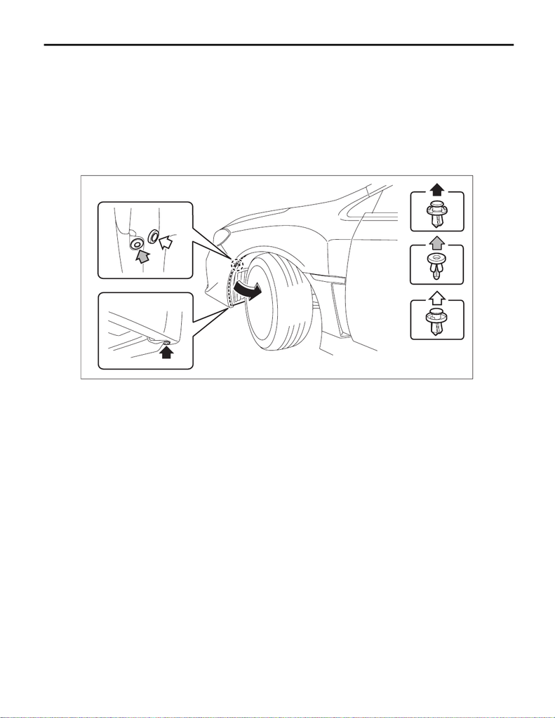

LI-39

Clearance/Parking Light Bulb

LIGHTING SYSTEM

20.Clearance/Parking Light Bulb

A: REMOVAL

NOTE:

Since the LED type is a non-disassembled part, it cannot be removed.

1) Disconnect the ground cable from battery. <Ref. to NT-5, BATTERY, NOTE, Note.>

NOTE:

For models other than STI model, disconnect the ground terminal from battery sensor.

turn over the mud guard - front.

sembly.>

B: INSTALLATION

1) Install the parking light bulb. <Ref. to LI-26, PARKING LIGHT BULB, ASSEMBLY, Headlight Assembly.>

2) Install the mud guard - front.

3) Connect the battery ground terminal. <Ref. to NT-5, BATTERY, NOTE, Note.>

NOTE:

For models other than STI model, connect the ground terminal to battery sensor.

LI-01717